# Pct_positivity_sims

Scenarios only testing Symptomatics:

assumptions- 10% of symptomatic COVID-19 cases are tested. Cases are only tested upon displaying symptoms. Symptoms show up 5 days after exposure event, tests results take 3 days to process, therefore test results are only counted in the fraction positive value 8 days after an individual’s exposure event.

Test sensitivity (PCR) is 95%, test specificity is 98%.

After a person is exposed we assume they remain infectious for 10 days, whether they are symptomatic cases or asymptomatic cases.

The number of daily tests increases throughout the 300 days of the simulated epidemic and reaches a maximum of 2000 tests per day at day 200. This level of daily testing is sustained for the remainder of the epidemic.

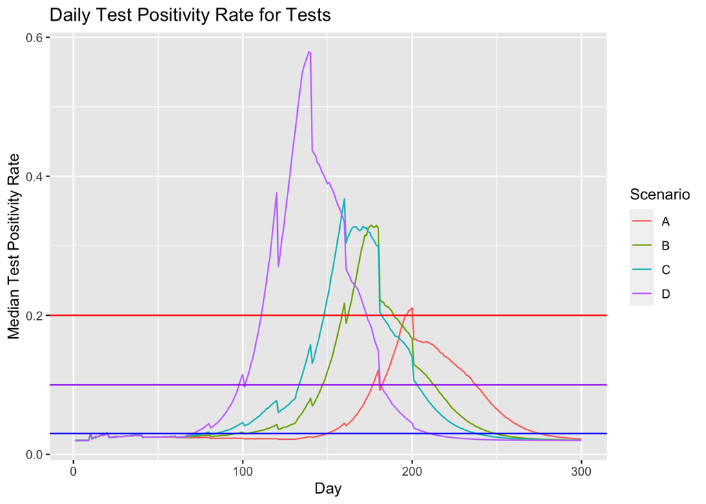

Number of days over the 300 simulation days that are below test positivity rate indicated.

|  | Days Below 20% | Days Below 10% | Days Below 3% |
| --- | --- | --- | --- |
| Scenario A | 296 | 241 | 175 |
| Scenario B | 271 | 235 | 148 |
| Scenario C | 266 | 231 | 142 |
| Scenario D | 237 | 217 | 159 |

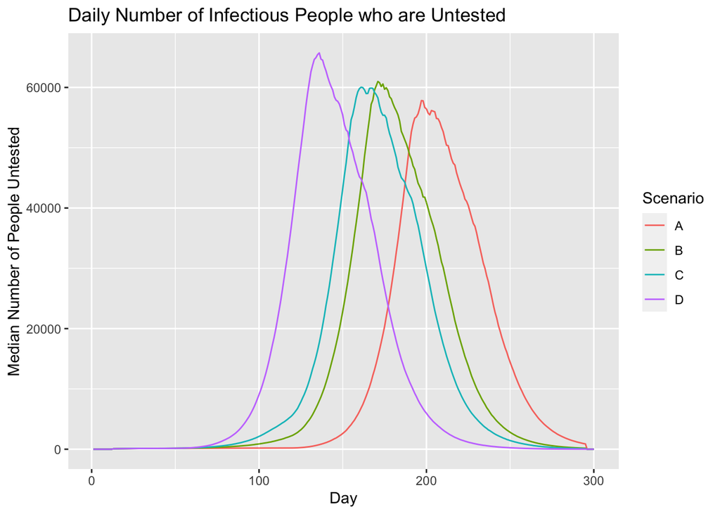

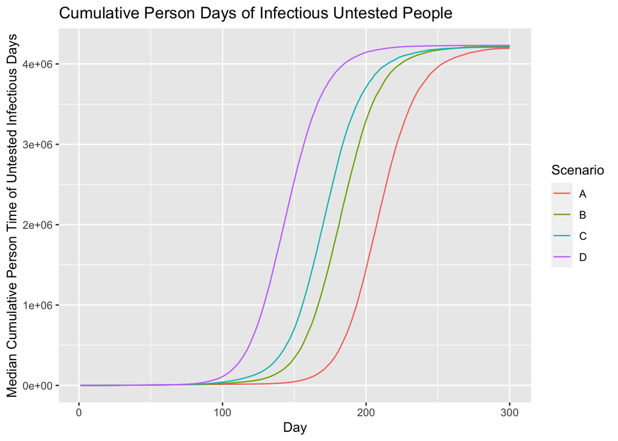

Scenarios testing Symptomatics and Asymptomatics:

Assumptions- 7% of symptomatic COVID-19 cases are tested. Cases are only tested upon displaying symptoms. Symptoms show up 5 days after exposure event, tests results take 3 days to process, therefore test results are only counted in the fraction positive value 8 days after an individual’s exposure event.

3/5% of asymptomatic COVID-19 cases are tested. Tests results take 3 days to process.

Test sensitivity (PCR) is 95%, test specificity is 98%.

After a person is exposed we assume they remain infectious for 10 days, whether they are symptomatic cases or asymptomatic cases.

The number of daily tests increases throughout the 300 days of the simulated epidemic and reaches a maximum of 2000 tests per day at day 200. This level of daily testing is sustained for the remainder of the epidemic.

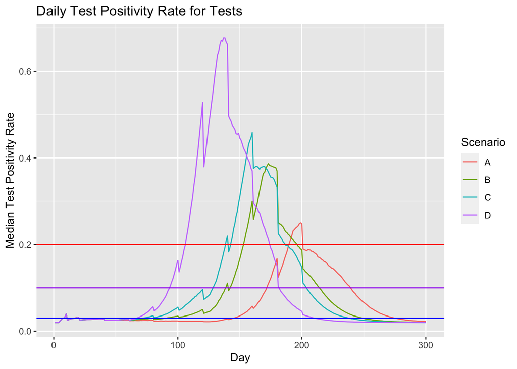

Number of days over the 300 simulation days that are below test positivity rate indicated.

|  | Days Below 20% | Days Below 10% | Days Below 3% |
| --- | --- | --- | --- |
| Scenario A | 289 | 232 | 165 |
| Scenario B | 257 | 226 | 135 |
| Scenario C | 254 | 225 | 129 |
| Scenario D | 232 | 212 | 150 |

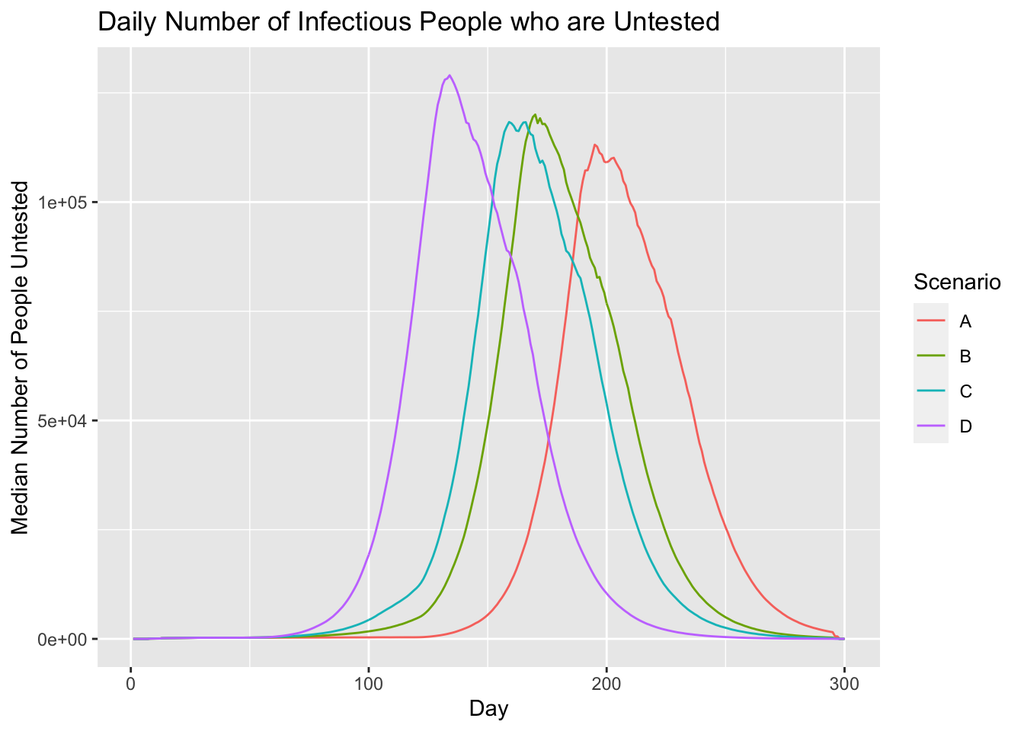

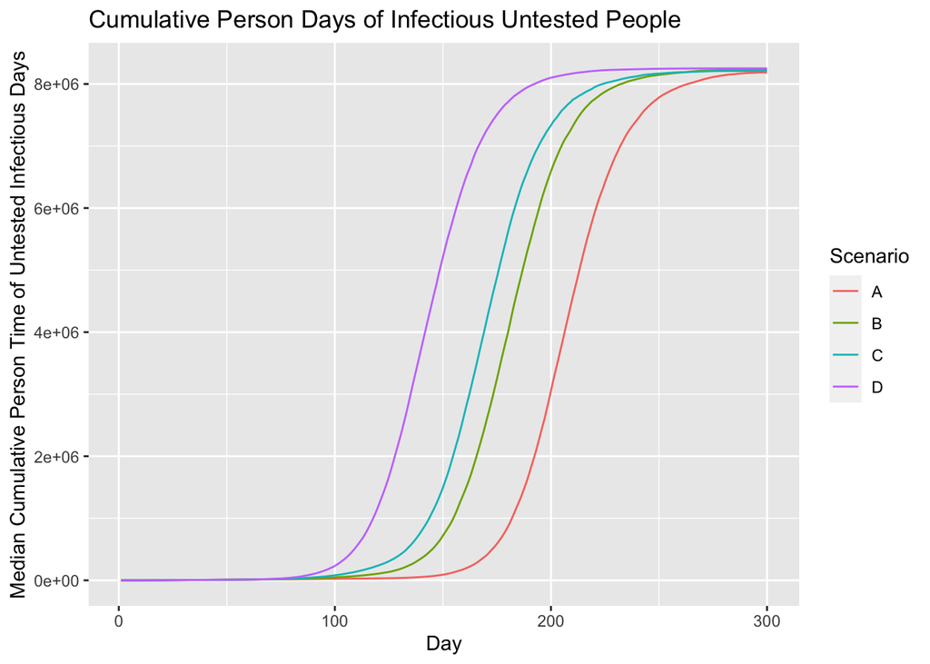

Scenarios testing Symptomatics and Asymptomatics with lower sensitivity and specificity:

Assumptions- 7% of symptomatic COVID-19 cases are tested. Cases are only tested upon displaying symptoms. Symptoms show up 5 days after exposure event, tests results take 3 days to process, therefore test results are only counted in the fraction positive value 8 days after an individual’s exposure event.

3/5% of asymptomatic COVID-19 cases are tested. Tests results take 3 days to process.

Test sensitivity (PCR) is 90%, test specificity is 95%.

After a person is exposed we assume they remain infectious for 10 days, whether they are symptomatic cases or asymptomatic cases.

The number of daily tests increases throughout the 300 days of the simulated epidemic and reaches a maximum of 2000 tests per day at day 200. This level of daily testing is sustained for the remainder of the epidemic.

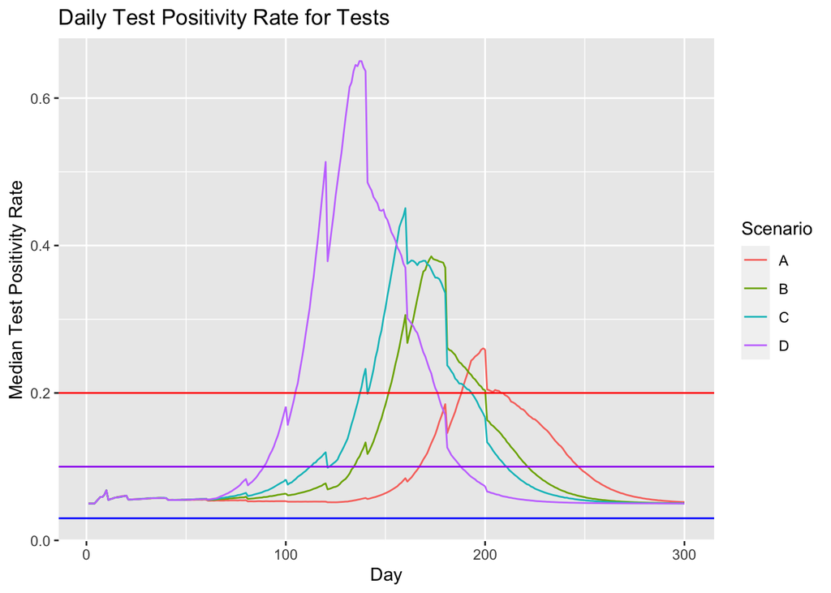

Number of days over the 300 simulation days that are below test positivity rate indicated.

|  | Days Below 20% | Days Below 10% | Days Below 3% |
| --- | --- | --- | --- |
| Scenario A | 281 | 221 | 0 |
| Scenario B | 251 | 213 | 0 |
| Scenario C | 245 | 203 | 0 |
| Scenario D | 228 | 201 | 0 |

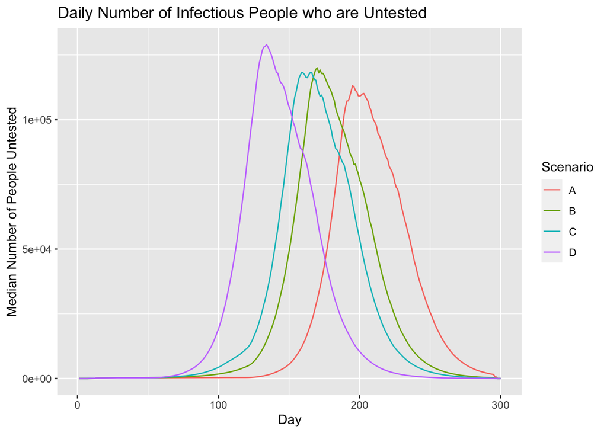

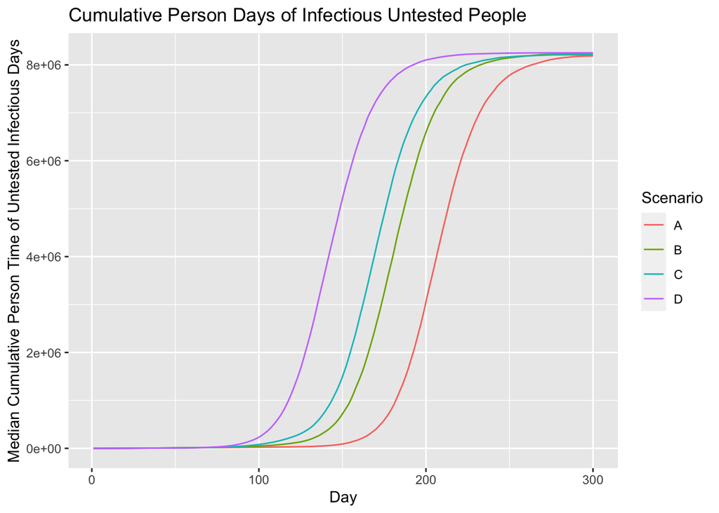